# homework5 rethinking

Liying Li

2024-02-13

[output not shown]

[output not shown]

[output not shown]

[output not shown]

[output not shown]

[output not shown]

[output not shown]

[output not shown]

[output not shown]

[output not shown]

[output not shown]

## Recap of the Bayes’ theorem question of the last homework for the request of Erin

explainations from book page 78 and page 84

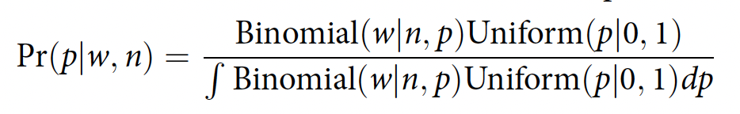

Denominator is to average likelihood and standardizes the posterior to sum to 1. The action is in the numerator, where the posterior probability of any particular value of p is seen again to be proportional to the product of the likelihood and prior

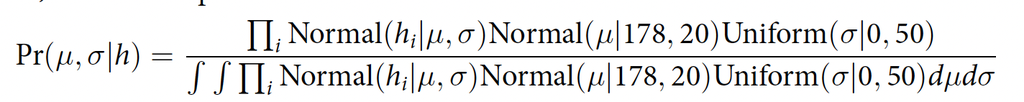

The door shape mark means multiplication of all values, that is because there is more than one observation in h in a distribution of height based on weight, so to get the joint likelihood across all the data points we have to computete the probability for each hi and then multiply all these likelihoods together. The demonator is the stack-up of two dimensions of priors’ integral for standardize to 1.

# 5E2

# 5E3.

Ti ∼ Normal(μi, σ) μi = α + βsSi + βfFi α ∼ Normal(0, 0.2) βs ∼ Normal(0, 0.5) βs ∼ Normal(0, 0.5) σ ∼ Exponential(1) #5E3 Suppose you have a single categorical predictor with 4 levels (unique values), labeled A, B, C D. Let Ai be an indicator variable that is 1 where case i is in category A. Also suppose Bi, Ci, and Di for the other categories. Now which of the following linear models are inferentially equivalent ways to include the categorical variable in a regression? Models are inferentially equivalent when it’s possible to compute one posterior distribution from the posterior distribution of another model “(2) µi = α + βAAi + βBBi + βCCi + βDDi”

# 5M1.

Invent your own example of a spurious correlation. An outcome variable should be correlated with both predictor variables. But when both predictors are entered in the same model, the correlation between the outcome and one of the predictors should mostly vanish (or at least be greatly reduced)

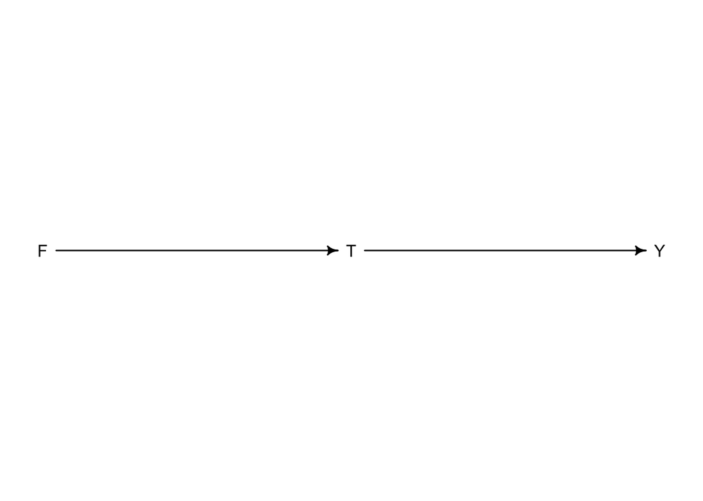

```r
library(dagitty)
dag5.1 <-dagitty("dag{F->T;T->Y}")
coordinates(dag5.1) <-list(x=c(F=0,T=1,Y=2),y=c(F=0,T=0,Y=0))
drawdag(dag5.1)
```

# 5M2.

Invent your own example of a masked relationship. An outcome variable should be correlated with both variables, but in opposite directions. And the two predictor variables should be with one another.”

Elevation influnces vegetation and temperature and ELevation influence vegetation through temperature change

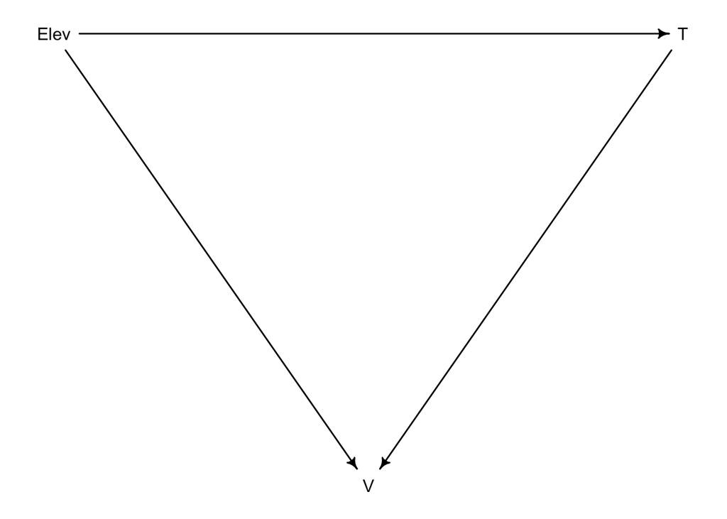

```r
library(dagitty)
dag5.1 <-dagitty("dag{T->V;Elev->T;Elev->V}")
coordinates(dag5.1) <-list(x=c(V=1,T=2,Elev=0),y=c(V=1,T=0,Elev=0))
drawdag(dag5.1)
```

## Hard question # 5H1. In the divorce example, suppose the DAG is: M->A->D. What are the implied conditional independencies of the graph? Are the data consistent with it?

```r
data(WaffleDivorce)
d <-list()
d$A <-standardize(WaffleDivorce$MedianAgeMarriage)
d$D <-standardize(WaffleDivorce$Divorce)
d$M <-standardize(WaffleDivorce$Marriage)
summary(d$A)
```

```
##    Min. 1st Qu.  Median    Mean 3rd Qu.    Max.
## -2.2949 -0.5862 -0.1238  0.0000  0.5597  2.9317
```

```r
cor1<-d %>%
  as.data.frame()%>%
  filter(A> -2 & A< -1)%>%
  select(M, D) %>%
  cor()
print(cor1)
```

```
##            M          D
## M  1.0000000 -0.7220723
## D -0.7220723  1.0000000
```

```r
cor2<-d %>%
  as.data.frame()%>%
  filter(A> -1 & A< 0)%>%
  select(M, D) %>%
  cor()
print(cor2)
```

```
##            M          D
## M 1.00000000 0.05918949
## D 0.05918949 1.00000000
```

```r
cor3<-d %>%
  as.data.frame()%>%
  filter(A> 0 & A< 1)%>%
  select(M, D) %>%
  cor()
print(cor3)
```

```
##           M         D
## M  1.000000 -0.341914
## D -0.341914  1.000000
```

```r
cor4<-d %>%
  as.data.frame()%>%
  filter(A> 0 & A< 1)%>%
  select(M, D) %>%
  cor()
print(cor4)
```

```
##           M         D
## M  1.000000 -0.341914
## D -0.341914  1.000000
```

```r
cor5<-d %>%
  as.data.frame()%>%
  filter(A> 1 & A< 2)%>%
  select(M, D) %>%
  cor()
print(cor5)
```

```
##         M       D
## M 1.00000 0.11092
## D 0.11092 1.00000
```

# 5H2.

Assuming that the DAG for the divorce example is indeed M->A->D, fit a new model and use it to estimate the counterfactual effect of halving a State’s marriage rate M. Use the counterfactual example from the chapter (starting on page 140) as a template.

```r
data(WaffleDivorce)
d1 <-list()
d1$A <-standardize(WaffleDivorce$MedianAgeMarriage)
d1$D <-standardize(WaffleDivorce$Divorce)
d1$M <-standardize(WaffleDivorce$Marriage)
m5H2 <-quap(
  alist(
## M->A->D
  D ~dnorm(mu,sigma),
  mu <-a+bM*M+bA*A,
  a ~dnorm(0,0.2),
  bM ~dnorm(0,0.5),
  bA ~dnorm(0,0.5),
  sigma ~dexp(1),
  ## M->A
  A ~ dnorm(mu_A,sigma_A),
  mu_A <- aA + bMA*M,
  aA ~ dnorm(0,0.2),
  bMA ~ dnorm(0,0.5),
  sigma_A ~ dexp(1)


), data=d1)
```

now we manipulate M

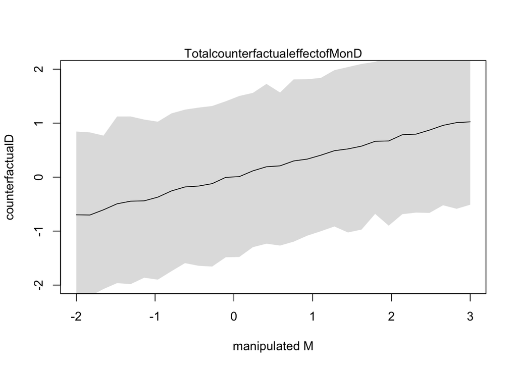

```r
# create simulation dataframe
M_seq <- seq(from = -2, to =3, length.out = 30)
sim_dat <- data.frame(M=M_seq)
#simulate A and D using M_seq
s<-sim(m5H2, data=sim_dat, vars=c("A","D"))

plot( sim_dat$M,colMeans(s$D),ylim=c(-2,2),type="l",
xlab="manipulated M",ylab="counterfactualD")
shade( apply(s$D,2,PI),sim_dat$M)
mtext( "TotalcounterfactualeffectofMonD")
```

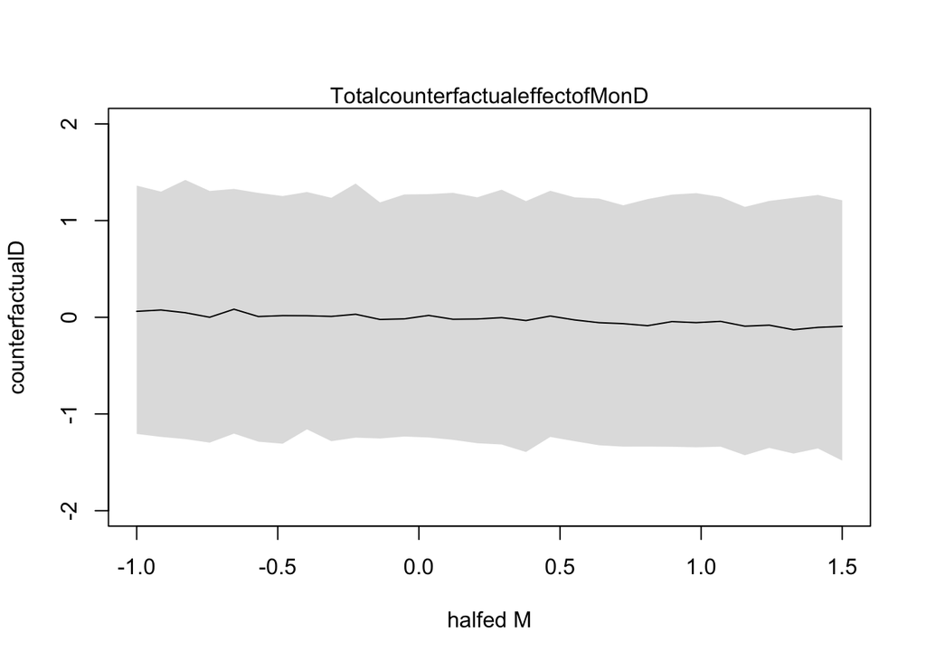

```r
# create simulation dataframe
M_seq <- seq(from = -1, to =1.5, length.out = 30)
sim_dat2 <- data.frame(M=M_seq)
#simulate A and D using M_seq
s2<-sim(m5H2, data=sim_dat2, vars=c("D", "A"))

plot( sim_dat2$M,colMeans(s2$D),ylim=c(-2,2),type="l",
xlab="halfed M",ylab="counterfactualD")
shade( apply(s2$D,2,PI),sim_dat2$M)
mtext( "TotalcounterfactualeffectofMonD")
```

After half M the effects on D becomes even weaker

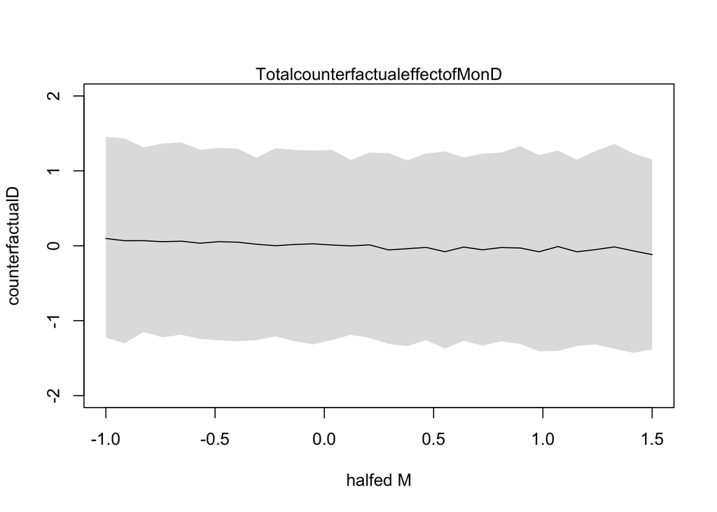

```r
# create simulation dataframe
M_seq <- seq(from = -1, to =1.5, length.out = 30)
sim_dat2 <- data.frame(M=M_seq, A=0)
#simulate A and D using M_seq
s2<-sim(m5H2, data=sim_dat2, vars=c("D"))

plot( sim_dat2$M,colMeans(s2),ylim=c(-2,2),type="l",
xlab="halfed M",ylab="counterfactualD")
shade( apply(s2,2,PI),sim_dat2$M)
mtext( "TotalcounterfactualeffectofMonD")
```

```r
mean(s2-s$D)
```

```
## [1] -0.1872913
```

# 5H3.

Return to the milk energy model, m5.7. Suppose that the true causal relationship among the variables is

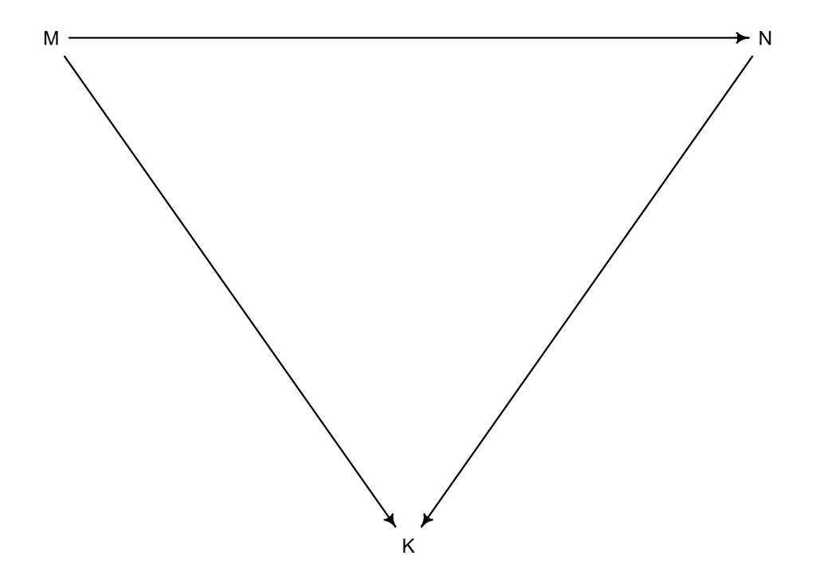

Now compute the counterfactual effect on K of doubling M. You will need to account for both the direct and indirect paths of causation. Use the counterfactual example from the chapter (starting on page 140) as a template.

```r
#load data

data(milk)
d <-milk
d$K <-standardize(d$kcal.per.g)
d$N <-standardize(d$neocortex.perc)
d$M <-standardize(log(d$mass))
#get complete cases with all three values
dcc <-d[complete.cases(d$K,d$N,d$M),]



m5.7_A <-quap(
alist(
  #M->K<-N
K ~dnorm(mu,sigma),
mu <-a+bN*N+bM*M,
a ~dnorm(0,0.2),
bN ~dnorm(0,0.5),
bM ~dnorm(0,0.5),
sigma ~dexp(1),
#M->N
N ~ dnorm(mu_N, sigma_N),
mu_N <- aN+bMN*M,
aN ~ dnorm(0, 0.2),
bMN ~ dnorm (0, 0.5),
sigma_N ~ dexp(1)

),data=dcc)
```

now we manipulate M

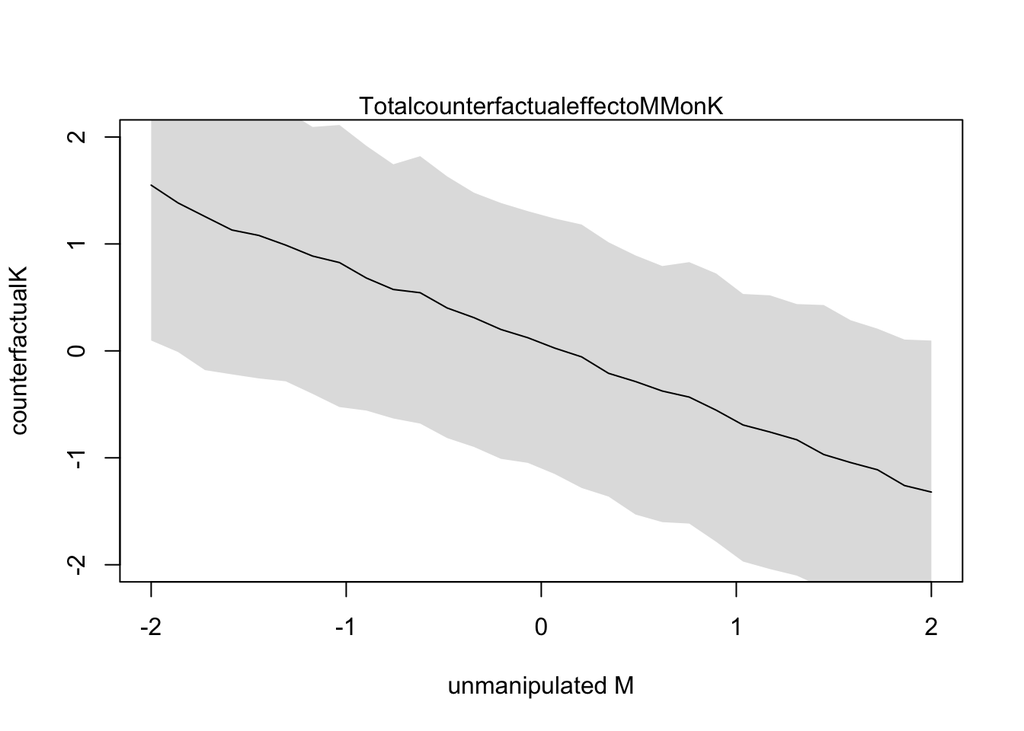

```r
# create simulation dataframe


M_seq1 <- seq(from = -2, to =2, length.out = 30)
sim_dat2 <- data.frame(M=M_seq1)
#simulate A and D using M_seq
s3<-sim(m5.7_A, data=sim_dat2, vars=c("K","N"))

plot( sim_dat2$M,colMeans(s3$K),ylim=c(-2,2),type="l",
xlab="unmanipulated M",ylab="counterfactualK")
shade( apply(s3$K,2,PI),sim_dat2$M)
mtext( "TotalcounterfactualeffectoMMonK")
```

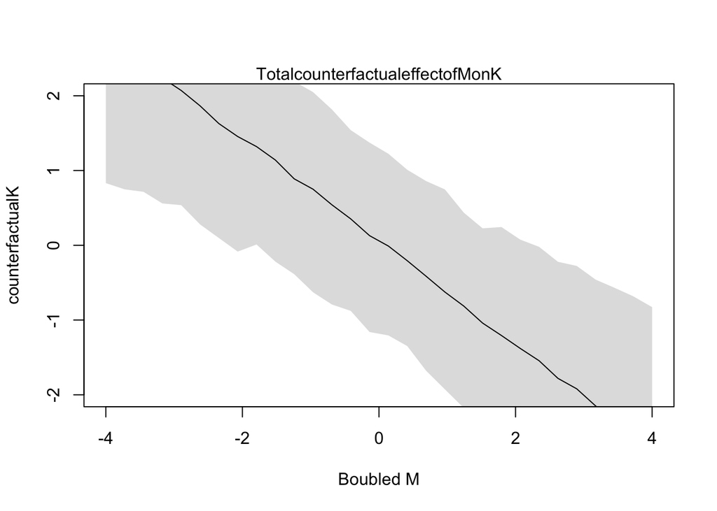

```r
# create simulation dataframe
M_seq2 <- seq(from = -4, to =4, length.out = 30)
sim_dat3 <- data.frame(M=M_seq2)
#simulate A and D using M_seq
s4<-sim(m5.7_A, data=sim_dat3, vars=c("K", "N"))

plot( sim_dat3$M,colMeans(s4$K),ylim=c(-2,2),type="l",
xlab="Boubled M",ylab="counterfactualK")
shade( apply(s4$K,2,PI),sim_dat3$M)
mtext( "TotalcounterfactualeffectofMonK")
```

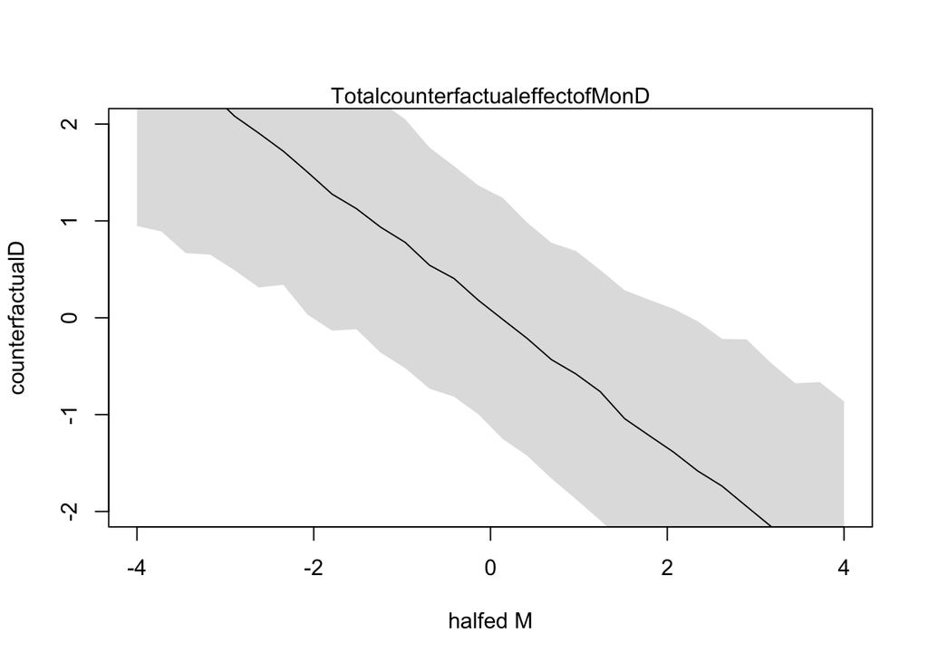

```r
# create simulation dataframe
M_seq2 <- seq(from = -4, to =4, length.out = 30)
sim_dat3 <- data.frame(M=M_seq2, N=0)
#simulate A and D using M_seq
s4<-sim(m5.7_A, data=sim_dat3, vars=c("K"))

plot( sim_dat3$M,colMeans(s4),ylim=c(-2,2),type="l",
xlab="halfed M",ylab="counterfactualD")
shade( apply(s4,2,PI),sim_dat3$M)
mtext( "TotalcounterfactualeffectofMonD")
```

# 5H4.

Here is an open practice problem to engage your imagination. In the divorce date, States in the southern United States have many of the highest divorce rates. Add the South indicator variable to the analysis. First, draw one or more DAGs that represent your ideas for how Southern American culture might influence any of the other three variables (D, M or A). Then list the testable implications if there are any, and fit one or more models to evaluate the implications. What do you think the influence of “Southerness” is?”

```r
#load data include population(P) and Slabe rate at 1860
data(WaffleDivorce)
d2 <-list()
d2$A <-standardize(WaffleDivorce$MedianAgeMarriage)
d2$D <-standardize(WaffleDivorce$Divorce)
d2$M <-standardize(WaffleDivorce$Marriage)
d2$P <-standardize(WaffleDivorce$Population)
d2$S <-standardize(WaffleDivorce$PropSlaves1860)
```

# first dag

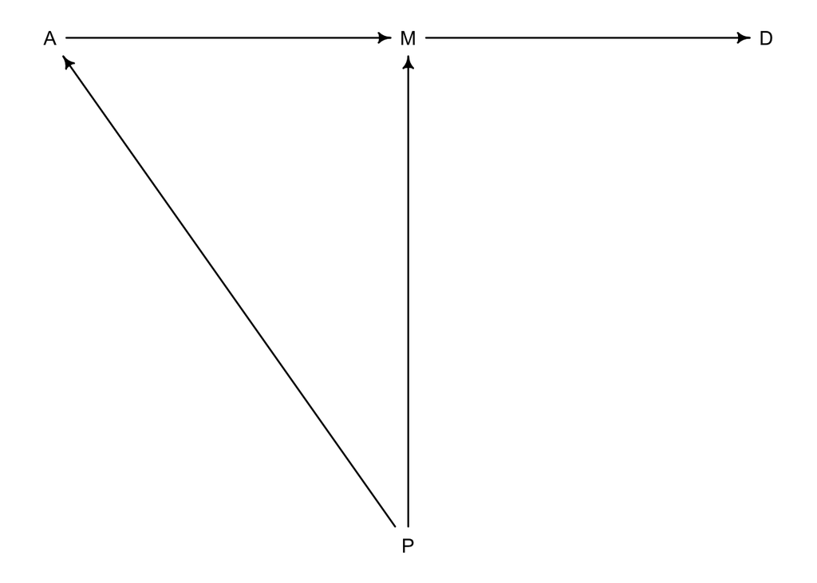

```r
library(dagitty)
dag5.1 <-dagitty("dag{A->M;M->D;P->A;P->M}")
coordinates(dag5.1) <-list(x=c(A=0,D=2,M=1, P=1),y=c(A=0,D=0,M=0, P=1))
drawdag(dag5.1)
```

# second dag

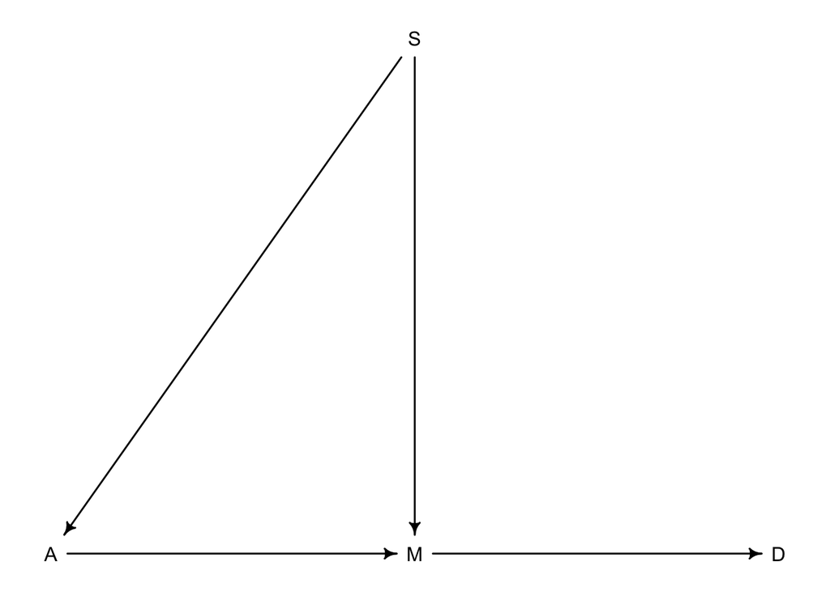

```r
library(dagitty)
dag5.1 <-dagitty("dag{A->M;M->D;S->A;S->M}")
coordinates(dag5.1) <-list(x=c(A=0,M=1,D=2, S=1),y=c(A=1,D=1,M=1, S=0))
drawdag(dag5.1)
```

```r
# The dags above very similar we only fit one model and the ohter's code would be identical
m5H4 <-quap(
  alist(
## A->M->D
  D ~dnorm(mu,sigma),
  mu <-a+bM*M+bA*A+bS*S,
  a ~dnorm(0,0.2),
  bM ~dnorm(0,0.5),
  bA ~dnorm(0,0.5),
  bS ~dnorm(0,0.5),
  sigma ~dexp(1),
  ## S->A
  A ~ dnorm(mu_A,sigma_A),
  mu_A <- aA + bSA*S,
  aA ~ dnorm(0,0.2),
  bSA ~ dnorm(0,0.5),
  sigma_A ~ dexp(1)


), data=d2)
```

```r
precis(m5H4)
```

```
##                  mean         sd        5.5%      94.5%
## a       -2.940244e-06 0.09590082 -0.15327097  0.1532651
## bM      -4.998042e-02 0.14922488 -0.28847060  0.1885098
## bA      -5.904364e-01 0.15008135 -0.83029541 -0.3505775
## bS       1.410060e-01 0.10868879 -0.03269964  0.3147117
## sigma    7.727528e-01 0.07659551  0.65033837  0.8951672
## aA      -2.755624e-06 0.11356911 -0.18150812  0.1815026
## bSA     -9.220578e-02 0.13426046 -0.30677993  0.1223684
## sigma_A  9.756051e-01 0.09616789  0.82191025  1.1293000
```

A has negative effect while S has positive effective on divorce rate which makes sense to me. bM doesn’t change a lot from the -0.07 in m5.3, that is M has week negative effects on divorce rate. We can plot both the residual plot and posterior plots to practice.

[figure not shown]

```r
mu <-link(m5H4)
mu_mean <-apply(mu$mu,2,mean)
mu_resid <-d2$D-mu_mean
plot(d2$S~d2$D,col=rangi2,ylim=range(d2$D),
xlab="Proportion of Slaves at 1860",ylab="Divorce Rate")
abline( a=0,b=0.14,lty=2)
for (i in 1:length(d2$D)) lines(rep(d2$D[i],1),mu_resid[i],col=rangi2)
```

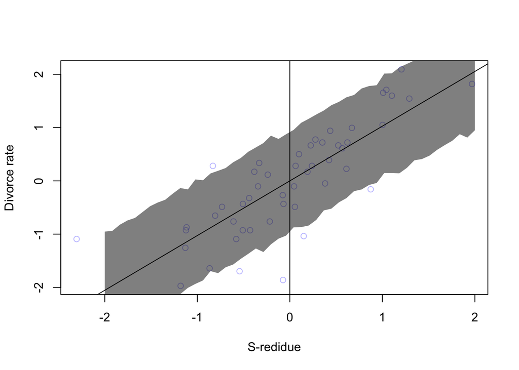

```r
resid_seq <-seq(-2,2, length.out=50)
d2$S_resid<-mu_resid
ml<-quap(
  alist(
    D ~ dnorm(mu, sigma),
    mu<-a+b*S_resid,
    c(a, b) ~ dnorm(0, 0.5),
    sigma ~ dexp(1)


  ), data=d2
)
# plot residue against divorce rate
plot( d2$D~mu_resid,col=col.alpha(rangi2,0.5),xlab="S-redidue",ylab="Divorce rate")
d3<-list()
d3$S_resid<-resid_seq
sim_data<-sim(ml, data=d3, vars=c("D"))

# draw MAP line

abline(lm(d2$D~mu_resid))
abline(v=0)


# draw HPDI
shade(apply(sim_data, 2, PI),resid_seq, col=col.alpha("black",0.5))
```

a differet version

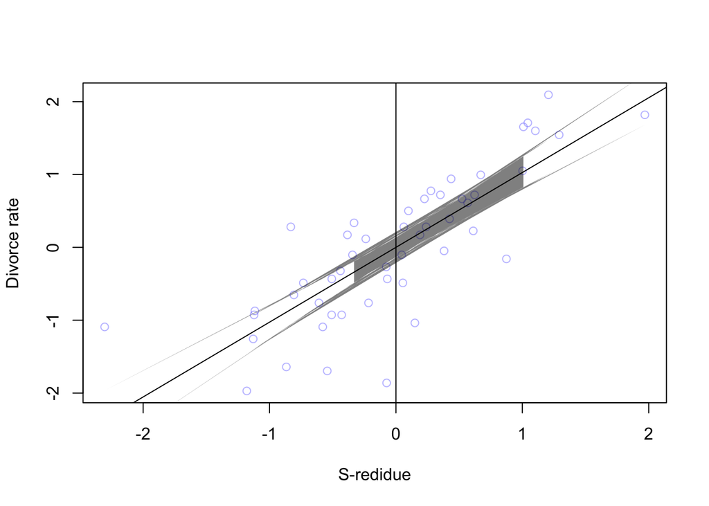

```r
# plot residue against divorce rate
plot( d2$D~mu_resid,col=col.alpha(rangi2,0.5),xlab="S-redidue",ylab="Divorce rate")

# draw MAP line

abline(lm(d2$D~mu_resid))
abline(v=0)


# draw HPDI
shade(apply(link(lm(d2$D~mu_resid)), 2, PI),mu_resid, col=col.alpha("black",0.5))
```

#posterior predictive plot

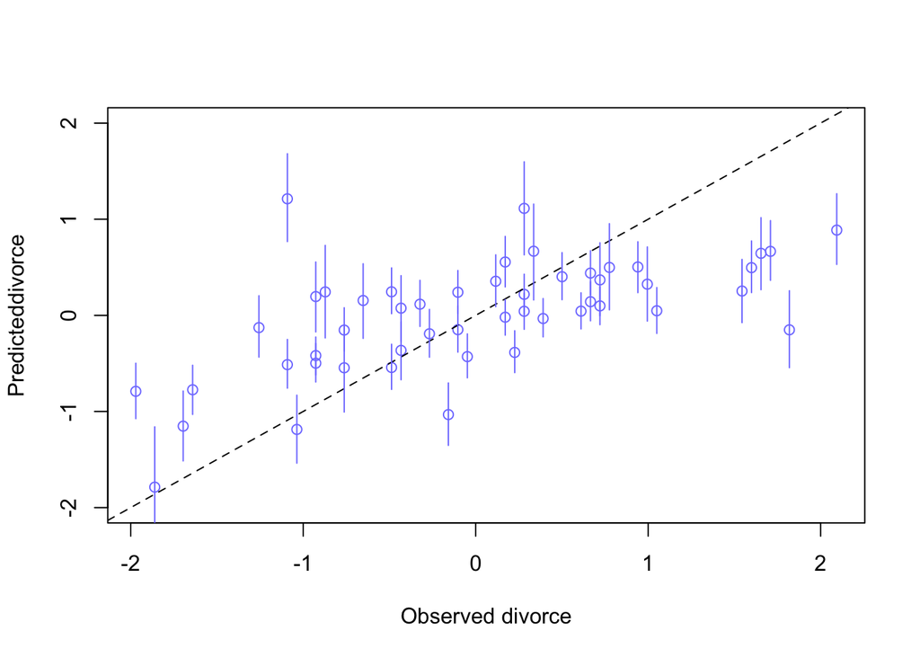

```r
mu_PI <-apply(mu$mu,2,PI)
# simulateobservations
# againnonewdata,sousesoriginaldata
D_sim <-sim(m5H4,n=1e4)
D_PI <-apply(D_sim,2,PI)

plot(mu_mean~d2$D,col=rangi2,ylim=c(-2,2),
xlab="Observed divorce",ylab="Predicteddivorce")
abline( a=0,b=1,lty=2)
for (i in 1:length(d2$D)) lines(rep(d2$D[i],2),mu_PI[,i],col=rangi2)
```